# Peer Assessment 1

## Loading and preprocessing the data

First, I must load the dataset into R. Second, load the libraries I will use. Finally, I convert the date variable from a factor variable into a date format. This will come in handy later.

```r
setwd("~/Fall 2015/Data Science Specialization/RepData")
data <- read.csv("activity.csv")
library(plyr)
library(Hmisc)
```

```r
library(ggplot2)
data$date <- as.Date(data$date)
```

## What is mean total number of steps taken per day?

In order to calculate the average steps taken in a day, I create dataset containing the sum of all intervals for each day. From here it is easy to calculate the mean and median steps taken per day and create a histogram.

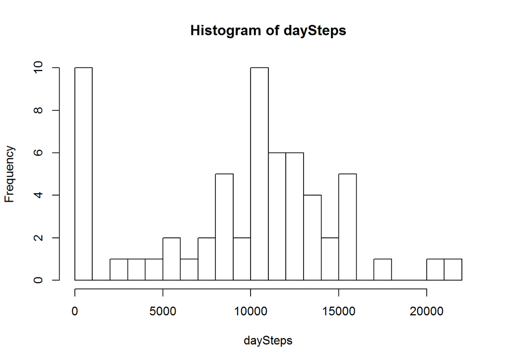

```r
daySteps <- tapply(data$steps, data$date, sum, na.rm=TRUE)
hist(daySteps, breaks = 20)
```

```r
mean(daySteps)
```

```
## [1] 9354.23
```

```r
median(daySteps)
```

```
## [1] 10395
```

## What is the average daily activity pattern?

Next, we want to look at how many steps were taken during each 5-minute interval. To do this we create a dataset containing the mean of each interval over all the days and then plot it using a line graph.

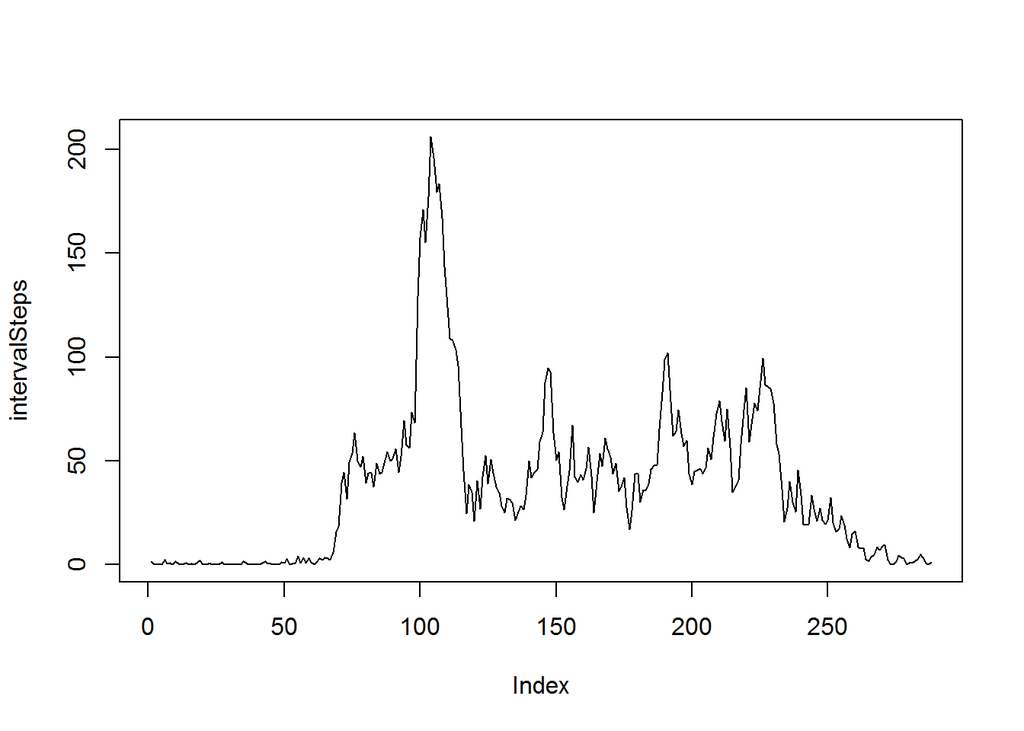

```r
intervalSteps <- tapply(data$steps, data$interval, mean, na.rm=TRUE)
plot(intervalSteps, type = "l")
```

Next, we check to see which five-minute interval has the highest average steps and see that it is the time between 8:35 and 8:40 AM.

```r
intervalSteps[which.max(intervalSteps)]
```

```
##      835
## 206.1698
```

## Imputing missing values

Next, I have to fill in all the missing values, or NAs. After summing up all the NAs, I create a second full dataset. I decide to substitute the mean steps in each interval to replace the NAs. I believe that this provides the most accurate substitution. I duplicated my dataset and saved the new one as data2, then used ddply to input the new values. A quick check confirms that there are no NAs in data2.

```r
sum(is.na(data$steps))
```

```
## [1] 2304
```

```r
data2 <- data
data2 <- ddply(data2, ~ interval, transform, steps = impute(steps, mean))
sum(is.na(data2$steps))
```

```
## [1] 0
```

```r
daySteps2 <- tapply(data2$steps, data2$date, sum, na.rm=TRUE)
mean(daySteps2)
```

```
## [1] 10766.19
```

```r
median(daySteps2)
```

```
## [1] 10766.19
```

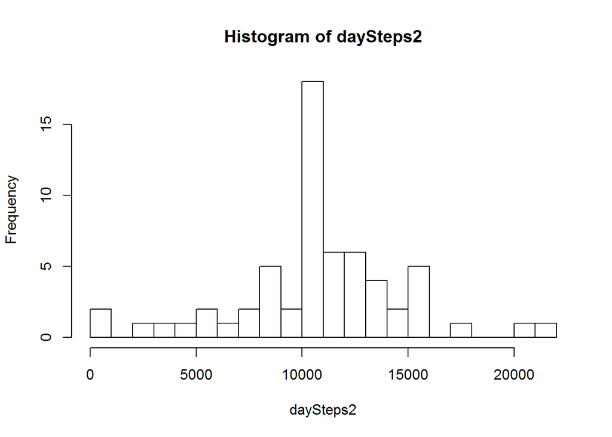

```r
hist(daySteps2, breaks = 20)
```

## Are there differences in activity patterns between weekdays and weekends? To accomplish this we first much create a variable that determines if a date is a weekday or weekend.

```r
weekday <- function(date) {
  # First we create a variable that uses the date to determine the day of the week (remember we converted data$date into a data format earlier).
  day <- weekdays(date)
  # Next we use and if/else statement to determine if that day is a weekday or weekend and return the correct value.
  if (day %in% c("Monday", "Tuesday", "Wednesday", "Thursday", "Friday"))
    return("weekday")
  else if (day %in% c("Saturday", "Sunday"))
    return("weekend")
}
# Finally, we use sapply to use the function created above to create a new column in our dataset.
data2$weekday <- sapply(data2$date, FUN=weekday)
```

Next, we use aggregate create to a variable that finds the means for each interval on the weekday and weekend. Finally, we use ggplot to create a panel of charts showing a time-series graph of mean steps per interval. Separate charts are created for weekdays and the weekend. The charts showing that there is a high spike in steps around the morning rush hour (6:00-9:00), before it stays steady for the rest of the day. A weekends, however, there is a much smaller spike and it does not begin till after 8:00, meanwhile it is higher throughout the remainder of the day.

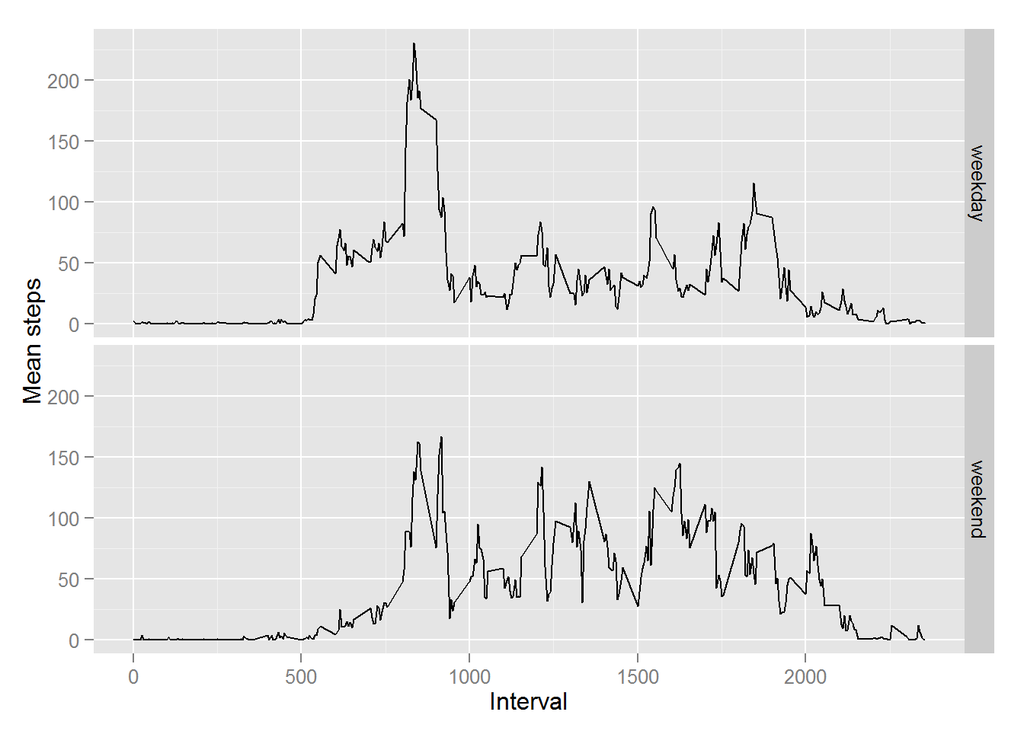

```r
dayComp <- aggregate(steps ~ interval + weekday, data=data2, mean)
ggplot(dayComp, aes(interval, steps)) + geom_line() + facet_grid(weekday ~ .) +
    xlab("Interval") + ylab("Mean steps")
```